# Bitirme_Odevi_Berkay_Bakac_Final copy

**Veri Seti Özeti**

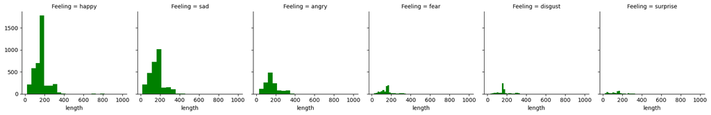

**Veri Setini Görselleştirme**

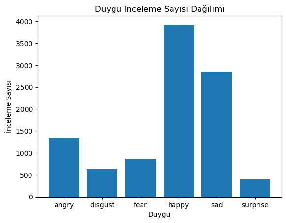

**Karar Ağacı Sınıflandırıcısını Uygulama**

```
Confusion matrix, without normalization
[[ 359    0    2   25    9    0]
 [   0  179    1   15    3    0]
 [   1    0  215   29    3    2]
 [  13    5   22 1135   39    8]
 [  13    2   10   65  733    7]
 [   0    1    0   14    2   94]]
```

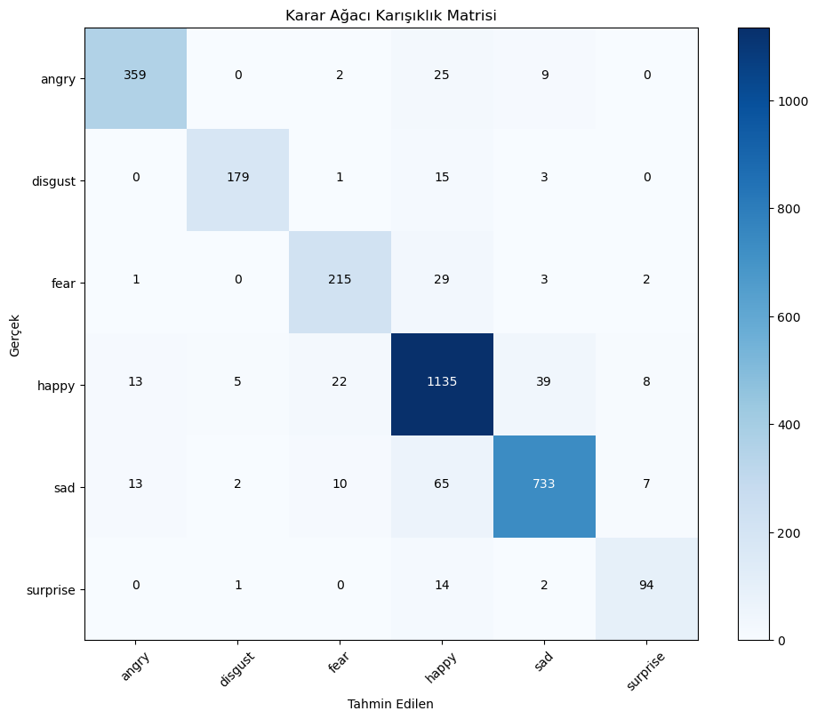

Karışıklık Matrisi (Confusion Matrix), modelin her sınıf için doğru ve yanlış tahminlerini özetleyen bir tablodur.

**Doğruluk Skoru**

```
Score: 90.32
```

**Sınıflandırma Raporu**

```
Sınıflandırma Raporu:
              precision    recall  f1-score   support

       angry       0.93      0.91      0.92       395
     disgust       0.96      0.90      0.93       198
        fear       0.86      0.86      0.86       250
       happy       0.88      0.93      0.91      1222
         sad       0.93      0.88      0.91       830
    surprise       0.85      0.85      0.85       111

    accuracy                           0.90      3006
   macro avg       0.90      0.89      0.89      3006
weighted avg       0.90      0.90      0.90      3006
```

```
Cross-Validation Scores: [0.41267465 0.52744511 0.56115826 0.74438342 0.66650025]
Average Cross-Validation Score: 0.5824323395146801
```

```
            importance
ed            0.122283
angry         0.025525
irritating    0.017233
annoying      0.016144
happy         0.016078
stun          0.012052
aggravated    0.011726
jealous       0.011638
outraged      0.011617
irritate      0.011378
anxiety       0.011148
astonish      0.010973
shock         0.010922
tensed        0.010772
dread         0.010621
sicken        0.010599
fright        0.010516
annoy         0.010175
sarcasm       0.010089
raped         0.010030
```

Feature Importance (Özellik Önemi) Özellik önemi, hangi özelliklerin model tarafından daha fazla dikkate alındığını gösterir. En önemli özellik "ed" olarak belirlenmiş ve diğer özellikler de sırasıyla önem taşımaktadır. Bu bilgi, modelin hangi özelliklere daha fazla ağırlık verdiğini anlamamıza yardımcı olur ve model optimizasyonu için kullanılabilir.

Özellik isimlerinden biri olan "ed", veri setinin yapısına bağlı olarak çeşitli anlamlar taşıyabilir. Örneğin, "education" (eğitim) ya da "emotion descriptor" (duygu tanımlayıcısı) olabilir. Bu, modelin bu özelliği karar verme sürecinde önemli bulduğu anlamına gelir.

Hyperparameter Optimization (Hiperparametre Optimizasyonu) En iyi parametreler:

- criterion: gini
- max_depth: None
- min_samples_leaf: 1
- min_samples_split: 5
- Best Cross-Validation Score: 0.8867484898368383

Hiperparametre optimizasyonu, modelin performansını artırmak için en uygun parametrelerin bulunması sürecidir. Bu sonuçlar, model için en iyi parametrelerin "gini" kriteri, sınırsız derinlik, minimum 1 yaprak örneği ve minimum 5 örnekle bölünme olduğunu göstermektedir.

```
Decision Tree Accuracy: 0.9055
Random Forest Accuracy: 0.8816
SVM Accuracy: 0.7851
Gradient Boosting Accuracy: 0.9015
```

Model Comparison (Model Karşılaştırması) Bu sonuçlar, Decision Tree ve Gradient Boosting algoritmalarının en yüksek doğruluk oranlarına sahip olduğunu göstermektedir.

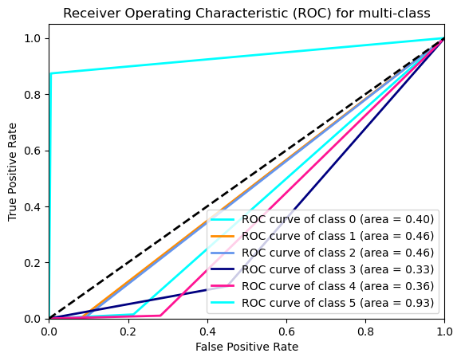

ROC Curve and AUC for Multi-Class Classification Görsel, multi-class sınıflandırma için ROC eğrilerini ve AUC değerlerini göstermektedir. Bu eğriler, modelin farklı sınıflar için ne kadar iyi performans gösterdiğini anlamamızı sağlar.

- ROC eğrisi (Receiver Operating Characteristic), doğru pozitif oranına (True Positive Rate) karşı yanlış pozitif oranını (False Positive Rate) gösterir.
- AUC (Area Under Curve): ROC eğrisinin altındaki alanı temsil eder. AUC değeri 1'e ne kadar yakınsa, modelin sınıflandırma performansı o kadar iyidir. Örneğin, AUC = 0.90, modelin %90 doğru sınıflandırma yaptığı anlamına gelir.

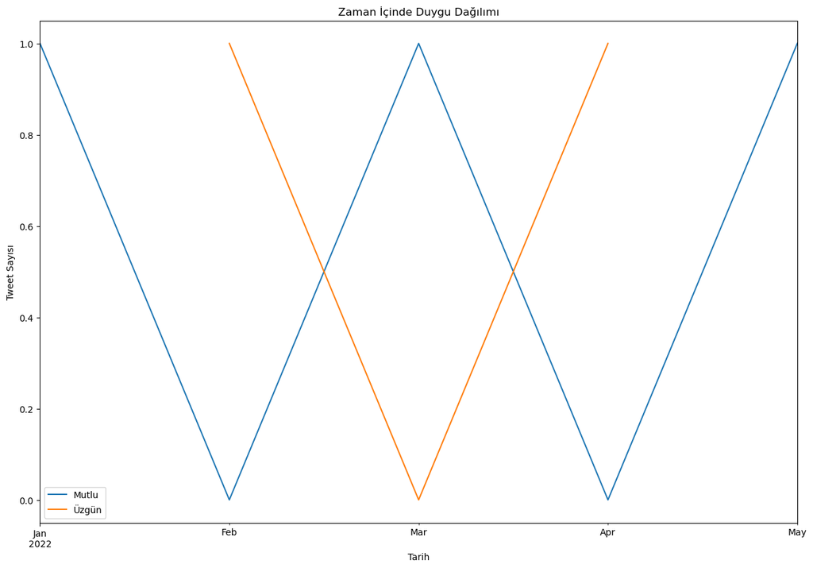

Zaman içinde duygu dağılımı: Görsel, zaman içinde belirli duyguların (örneğin, "Mutlu" ve "Üzgün") dağılımını görebilirsiniz. Her bir çizgi, belirli bir duygunun zaman içinde kaç kez ifade edildiğini göstermektedir. Aylık bazda toplanan bu veriler, belirli zaman dilimlerinde hangi duygunun daha baskın olduğunu anlamanıza yardımcı olur. Değerlendirme:

1. Duygu Değişikliklerini İzleme: Grafikteki çizgiler, belirli bir zaman diliminde hangi duygunun daha yaygın olduğunu gösterir. Örneğin, belirli bir ayda "Mutlu" tweetlerin sayısında bir artış, o dönemde genel olarak daha olumlu bir ruh hali olduğunu gösterebilir.
2. Trend Analizi: Zaman içinde duyguların nasıl değiştiğini gözlemlemek, genel ruh hali değişiklikleri hakkında bilgi verebilir. Örneğin, "Üzgün" tweetlerin sayısında bir artış, o dönemde olumsuz bir olayın yaşandığını gösterebilir.
3. Sosyal Medya Analizi: Sosyal medya üzerindeki genel ruh halini analiz etmek ve belirli olayların bu ruh haline nasıl etki ettiğini görmek için kullanılabilir. Örneğin, önemli bir olaydan sonra duygusal tepkiler incelenebilir.

# **Sonuç**